# Going Mobile: Day Zero

First recording, documenting the launch of the migration to mobile living. Covers initial mindset, thought process and approach.

[video not shown]

# Notes

Objectives:

1. Off-grid, self-sustaining van
   - 100% modular and mobile
   - Live, sleep, cook, eat, etc.
2. Everything else in the workspace
   - Truly an office, not a living space
   - All sentimental items in ~4-6 milk crates
   - Contained enough to fall back to a 2nd storage locker
3. Storage is only for infrastructure assets
   - Stronghold and safekeeping of rarely used gear
4. Everything should be moveable in the van
   - Ideally, able to transport the whole in 2 trips or less

Layers:

1. Brain, Body and EDC (Every Day Carry)
2. Backpack / BOB (Bug Out Bag)
3. Vehicle – Van Living (& Gym Membership)
4. Workspace – Office Space
5. Storage – Storage Locker

WORK: everything in a container or bag… “a place for everything, and everything in its place”… WORK: Where you “live” is defined by where you eat and where you sleep. WORK: Gym membership… WORK: link back to Going Mobile main page… WORK: add disclaimers to videos and site, for all…

# Checkpoints

- 2023-03-15 Recording Equipment: Initial Setup
- 2023-04-08 Decision – Going Mobile
- 2023-04-12 Started – Storage Locker and Office Space
- 2023-04-19 Power Grid: Van Solar Installation
- 2023-04-25 Moving Madness
- 2023-04-26 Office Space: Initial Dump
- 2023-05-12 Office Space: First Clean Up
- 2023-05-21 Office Space: Second Clean Up

# Pictures

## 2023-04-25 Moving Madness

[figure not shown]

[figure not shown]

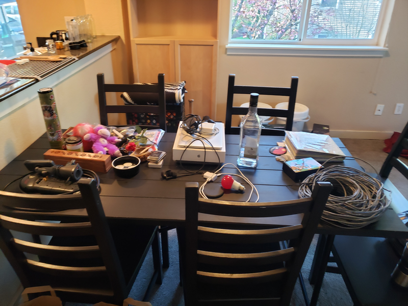

[figure not shown]

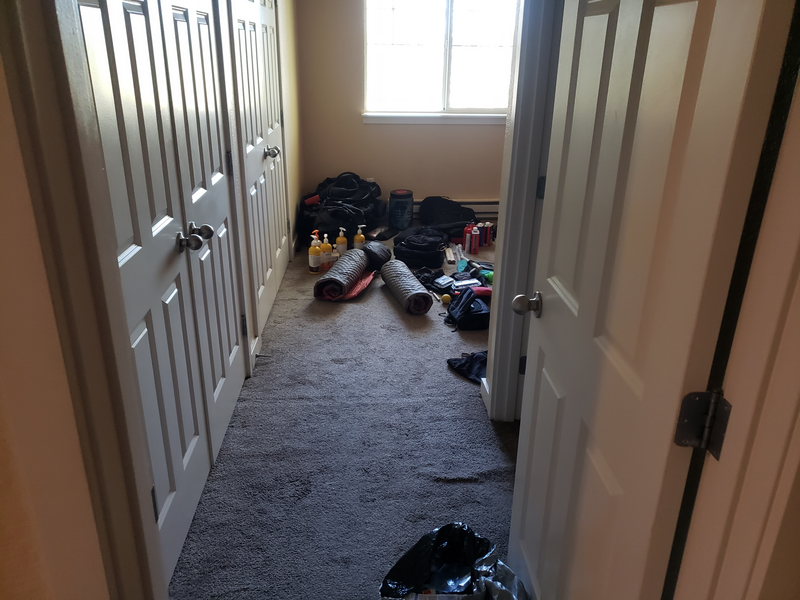

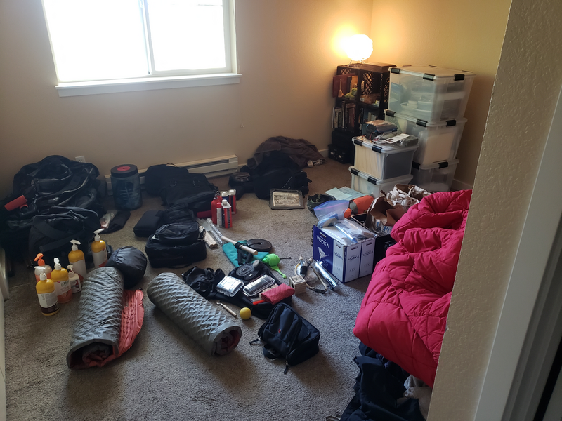

*This page and all embedded images and video are for informational purposes only, and do not come with any guarantees or representations of accuracy. I could be totally wrong.*

*Gary the Gear Guy, and Gary Gear Guy LLC, disclaim any and all liability to any party, for any reason. Yes, this means you.*

*By attempting to follow any aspect of this page or embedded images or video, you are agreeing that you are responsible for all the consequences of your actions. It’s all on you.*

*Other than the logo, none of the content on this site or on my linked websites was generated by (AI) artificial intelligence. I do my own work and express my own thoughts.*